# Survey Statistics – Day 2 Survey Weights with R

### The `survey_mean()` function

What difference does it make to use country population weights? In some cases a bit, in others not much. Let us look at the average age:

```r
# Without weighting
mean(data$agea, na.rm = T)
```

```
## [1] 49.57983
```

```r
# With population weights
data %>%
  as_survey(weights = c(pweight)) %>%
  summarize(lr_m = survey_mean(agea, na.rm = T))
```

```
## # A tibble: 1 x 2
##    lr_m lr_m_se
##   <dbl>   <dbl>
## 1  49.7   0.141
```

Considering the error, the difference between weighted and unweighted data is almost negligible. But let’s look at the average left-right self placement. The variable `lrscale` goes from `0` (left) to `10` (right) with `5` being the exact center.

```r
# Without weighting
mean(data$lrscale, na.rm = T)
```

```
## [1] 5.019931
```

```r
# With population weight
data %>%
  as_survey(weights = c(pweight)) %>%
  summarize(lr_m = survey_mean(lrscale, na.rm = T))
```

```
## # A tibble: 1 x 2
##    lr_m lr_m_se
##   <dbl>   <dbl>
## 1  4.93  0.0174
```

```r
# With population weight and design weight
data %>%
  as_survey(weights = c(dweight, pweight)) %>%
  summarize(lr_m = survey_mean(lrscale, na.rm = T))
```

```
## # A tibble: 1 x 2
##    lr_m lr_m_se
##   <dbl>   <dbl>
## 1  4.95  0.0185
```

Here, if we take into account the country population sizes, the mean self placement of the respondent gets shifted a bit on the left. However, once we take into account the design weight, the mean gets shifted a little bit on the right again. What do these results imply?

Let us compare female and male respondents. Is there a difference in terms of left-right self placement? Does this difference change across countries? Let us look first at the unweighted data.

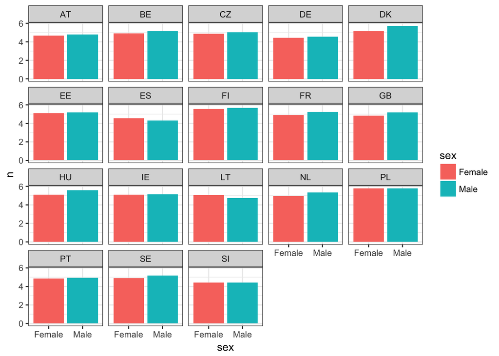

```r
# Create summary data
lr_gen <- data %>%
  mutate(sex = ifelse(gndr == 1, "Male", "Female")) %>%
  group_by(cntry, sex) %>%
  summarize(n = mean(lrscale, na.rm = T))

# Plot it
ggplot(lr_gen, aes(x = sex, y = n)) +
  geom_bar(aes(fill = sex), stat = "identity") +
  facet_wrap(~cntry) +
  theme_bw()
```

First we apply the design weight. Notice that now we have standard errors on the frequencies as well, so we can add error bars to our plots.

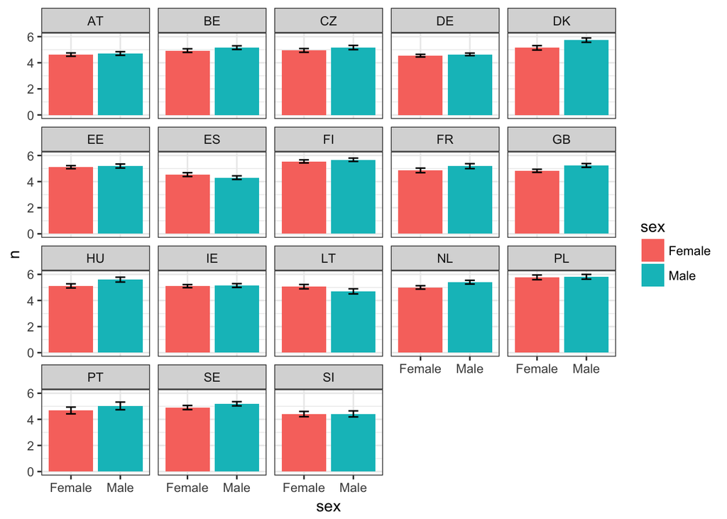

```r
# Create summary data
lr_gen_w1 <- data %>%
  mutate(sex = ifelse(gndr == 1, "Male", "Female")) %>%
  as_survey_design(weights = c(dweight)) %>%
  group_by(cntry, sex) %>%
  summarize(n = survey_mean(lrscale, na.rm = T, vartype = "ci"))

# Plot it
ggplot(lr_gen_w1, aes(x = sex, y = n)) +
  geom_bar(aes(fill = sex), stat = "identity") +
  geom_errorbar(aes(ymin = n_low, max = n_upp), width = 0.2) +
  facet_wrap(~cntry) +
  theme_bw()
```

Then we apply the design weight and the post-stratification weight together.

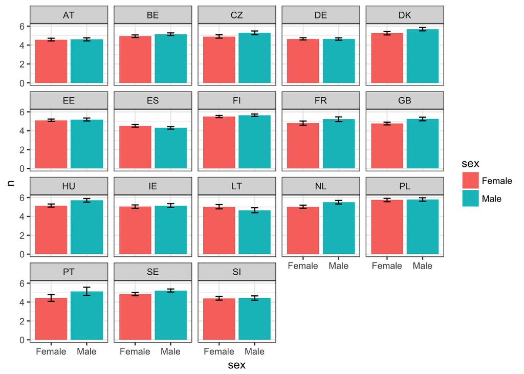

```r
# Create summary data
lr_gen_w2 <- data %>%
  mutate(sex = ifelse(gndr == 1, "Male", "Female")) %>%
  as_survey_design(weights = c(dweight, pspwght)) %>%
  group_by(cntry, sex) %>%
  summarize(n = survey_mean(lrscale, na.rm = T, vartype = "ci"))

# Plot it
ggplot(lr_gen_w2, aes(x = sex, y = n)) +
  geom_bar(aes(fill = sex), stat = "identity") +
  geom_errorbar(aes(ymin = n_low, max = n_upp), width = 0.2) +
  facet_wrap(~cntry) +
  theme_bw()
```

### Regression with weights

Of course you can also run a regression model including weights in the calculation. The `survey` package includes several functions to do that. Here we just make an example to answer the following research question: how do attitudes towards immigration correlate with left-right self placement in Europe? To do so, we run a regression model with `lrscale` as dependent variable, and a set of attitudes towards immigration as predictors. We do not talk about causation here: we just want to see how the variables correlate. The predictors are:

- `imsmetn`: Allow many/few immigrants of same race/ethnic group as majority
- `imdfetn`: Allow many/few immigrants of different race/ethnic group from majority
- `impcntr`: Allow many/few immigrants from poorer countries in Europe
- `imbgeco`: Allow many/few immigrants from poorer countries outside Europe
- `imueclt`: Immigration bad or good for country’s economy
- `imwbcnt`: Country’s cultural life undermined or enriched by immigrants

First, we run a simple linear regression model with all these variables predicting left-right self placement. We use the `glm()` function from base R, which fits a regression model using maximum likelihood estimation. It can be used with a variety of dependent variables, here since our outcome variable is an 11-point scale it will assume by default a Gaussian distribution.

```r
m_1 <- glm(lrscale~imsmetn + imdfetn + impcntr + imbgeco + imueclt + imwbcnt, data = data)
summary(m_1)
```

```
##
## Call:
## glm(formula = lrscale ~ imsmetn + imdfetn + impcntr + imbgeco +
##     imueclt + imwbcnt, data = data)
##
## Deviance Residuals:
##     Min       1Q   Median       3Q      Max
## -6.0171  -1.2281  -0.0422   1.2796   5.9129
##
## Coefficients:
##              Estimate Std. Error t value Pr(>|t|)
## (Intercept)  4.148589   0.084227  49.255  < 2e-16 ***
## imsmetn     -0.043641   0.023517  -1.856   0.0635 .
## imdfetn      0.178009   0.027294   6.522 7.06e-11 ***
## impcntr      0.230499   0.022168  10.398  < 2e-16 ***
## imbgeco      0.033147   0.007589   4.368 1.26e-05 ***
## imueclt     -0.048504   0.007693  -6.305 2.92e-10 ***
## imwbcnt      0.011733   0.008730   1.344   0.1789
## ---
## Signif. codes:  0 '***' 0.001 '**' 0.01 '*' 0.05 '.' 0.1 ' ' 1
##
## (Dispersion parameter for gaussian family taken to be 4.603576)
##
##     Null deviance: 133091  on 28210  degrees of freedom
## Residual deviance: 129839  on 28204  degrees of freedom
##   (6349 observations deleted due to missingness)
## AIC: 123142
##
## Number of Fisher Scoring iterations: 2
```

Then we run it on weighted data. To do so, we first need to create a “weighted data” object. We can do so with the syntax we saw already. We use all weights that we have.

```r
data_we <- data %>%
  as_survey(weights = c(dweight, pspwght, pweight))
```

Then we run the regression using the `svyglm()` function from the `survey` package.

```r
m_2 <- svyglm(lrscale~imsmetn + imdfetn + impcntr + imbgeco + imueclt + imwbcnt, design = data_we)
summary(m_2)
```

```
##
## Call:
## svyglm(formula = lrscale ~ imsmetn + imdfetn + impcntr + imbgeco +
##     imueclt + imwbcnt, design = data_we)
##
## Survey design:
## Called via srvyr
##
## Coefficients:
##             Estimate Std. Error t value Pr(>|t|)
## (Intercept)  4.41657    0.15427  28.630  < 2e-16 ***
## imsmetn     -0.11855    0.04629  -2.561   0.0104 *
## imdfetn      0.27853    0.05195   5.362 8.31e-08 ***
## impcntr      0.22445    0.04264   5.264 1.42e-07 ***
## imbgeco      0.02684    0.01469   1.828   0.0676 .
## imueclt     -0.09997    0.01553  -6.438 1.23e-10 ***
## imwbcnt      0.00337    0.01805   0.187   0.8519
## ---
## Signif. codes:  0 '***' 0.001 '**' 0.01 '*' 0.05 '.' 0.1 ' ' 1
##
## (Dispersion parameter for gaussian family taken to be 4.441555)
##
## Number of Fisher Scoring iterations: 2
```

Some results seem to change quite a bit, so for instance, some variables that were significant before are not significant any longer. How do you interpret this?